# Project Foundations for Data Science: FoodHub Data Analysis

**Marks: 60**

### Context

The number of restaurants in New York is increasing day by day. Lots of students and busy professionals rely on those restaurants due to their hectic lifestyles. Online food delivery service is a great option for them. It provides them with good food from their favorite restaurants. A food aggregator company FoodHub offers access to multiple restaurants through a single smartphone app.

The app allows the restaurants to receive a direct online order from a customer. The app assigns a delivery person from the company to pick up the order after it is confirmed by the restaurant. The delivery person then uses the map to reach the restaurant and waits for the food package. Once the food package is handed over to the delivery person, he/she confirms the pick-up in the app and travels to the customer's location to deliver the food. The delivery person confirms the drop-off in the app after delivering the food package to the customer. The customer can rate the order in the app. The food aggregator earns money by collecting a fixed margin of the delivery order from the restaurants.

### Objective

The food aggregator company has stored the data of the different orders made by the registered customers in their online portal. They want to analyze the data to get a fair idea about the demand of different restaurants which will help them in enhancing their customer experience. Suppose you are hired as a Data Scientist in this company and the Data Science team has shared some of the key questions that need to be answered. Perform the data analysis to find answers to these questions that will help the company to improve the business.

### Data Description

The data contains the different data related to a food order. The detailed data dictionary is given below.

### Data Dictionary

- order_id: Unique ID of the order
- customer_id: ID of the customer who ordered the food
- restaurant_name: Name of the restaurant
- cuisine_type: Cuisine ordered by the customer
- cost: Cost of the order
- day_of_the_week: Indicates whether the order is placed on a weekday or weekend (The weekday is from Monday to Friday and the weekend is Saturday and Sunday)
- rating: Rating given by the customer out of 5
- food_preparation_time: Time (in minutes) taken by the restaurant to prepare the food. This is calculated by taking the difference between the timestamps of the restaurant's order confirmation and the delivery person's pick-up confirmation.
- delivery_time: Time (in minutes) taken by the delivery person to deliver the food package. This is calculated by taking the difference between the timestamps of the delivery person's pick-up confirmation and drop-off information

### Initial Hypothesis

- Cuisine type can influence in orders requested.
- During Weekdays frequency of orders increase.
- Lower costs are more frequent.
- Greatest-rated restaurants are preferred.
- Total delivery time influence the frequency of orders.
- Total order time (Food preparation time + delivery time) influence the frequency of orders.
- Cuisine type preferences are different between workdays and weekdays.
- Customers always have multiple cuisine types preferred.

### Let us start by importing the required libraries

```python
# import libraries for data manipulation
import numpy as np
import pandas as pd

# import libraries for data visualization
import matplotlib.pyplot as plt
import seaborn as sns

# Others
from copy import deepcopy

%matplotlib inline
```

### Defining some functions to use during the analysis

```python
# These functions have different purposes and will be used during the univariate analysis
import matplotlib.patheffects as path_effects
import matplotlib as mpl

from scipy.stats import pearsonr


# Global variable to use in plots.
suptitle_param = dict(color='darkslategray', weight='bold', fontsize='x-large')


def get_df_displot(df):
    """Displot of all numerical variables presented in the passed dataframe.
    df: dataframe with at least one numerical variable.
    """
    df_melt = df.select_dtypes(include=np.number).fillna(0).melt()
    df_melt.value = pd.to_numeric(df_melt.value, errors='coerce')

    def central_tendency(x, **kwargs):
        ax = plt.gca()
        mean = x.mean()
        ax.axvline(mean, c='k', ls='--', lw=2.5)
        ax.set_title('{}\nMean: {:,.2f}'.format(ax.get_title(), mean))

    sns.set(font_scale=1.5)
    g = sns.displot(data=df_melt,
                    x="value", hue="variable", col="variable", legend=False, common_norm=False,
                    kind="kde", facet_kws={'sharex': False, 'sharey': False})
    g.map(central_tendency, 'value')
    plt.suptitle('Univariate Analysis - Numerical Features', **suptitle_param)
    plt.subplots_adjust(top=0.85)
    plt.tight_layout()
    plt.show()


def get_feature_hist_and_boxplot(feature, bins="auto", figsize=(6, 3)):
    """ Boxplot and histogram combined
    feature: pandas.series
    bins: number of bins (default "auto")
    figsize: size of fig (default (6, 3))
    """
    mean = feature.mean()
    median = np.median(feature)
    min_v = feature.min()
    max_v = feature.max()

    sns.set(font_scale=.75)
    f, (ax_box, ax_hist) = plt.subplots(
        nrows=2,  # Number of rows of the subplot grid
        sharex=True,  # The X-axis will be shared among all the subplots
        gridspec_kw={"height_ratios": (.25, .75)},
        figsize=figsize
    )

    # Creating the subplots
    # Boxplot will be created and the mean value of the column will be indicated using some symbol
    sns.boxplot(x=feature, ax=ax_box, color='red',
                showmeans=True,
                meanprops={"marker":"o",
                           "markerfacecolor":"goldenrod",
                           "markeredgecolor":"silver",
                           "markersize":"10"})

    text = ax_box.annotate("Mean {:,.4f}".format(mean), fontsize='small',
                           xy=(mean, -0.15), color='g', weight='bold', ha='center')
    text.set_path_effects([path_effects.Stroke(linewidth=3,
                                               foreground='black'), path_effects.Normal()])
    ax_box.set_ylabel('BoxPlot\n')
    ax_box.set_xlabel('')

    # For histogram
    sns.histplot(x=feature, kde=False, bins=bins, ax=ax_hist)
    ax_hist.axvline(mean, color='g', linestyle='--')      # Add mean to the histogram
    ax_hist.axvline(median, color='black', linestyle='-') # Add median to the histogram

    min_max_pos = 0.05 * ax_hist.get_ylim()[1]
    text = ax_hist.annotate("Median {:,.4f}".format(median), fontsize='small',
                            xy=(median, ax_hist.get_ylim()[1]/2),
                            color='w', weight='bold', ha='center')
    text.set_path_effects([path_effects.Stroke(linewidth=3, foreground='k'), path_effects.Normal()])
    text = ax_hist.annotate("Min {:,.4f}".format(min_v), fontsize='small',
                            xy=(min_v, min_max_pos),
                            color='w', weight='bold', ha='left')
    text.set_path_effects([path_effects.Stroke(linewidth=3, foreground='k'), path_effects.Normal()])
    text = ax_hist.annotate("Max {:,.4f}".format(max_v), fontsize='small',
                            xy=(max_v, min_max_pos),
                            color='w', weight='bold', ha='right')
    text.set_path_effects([path_effects.Stroke(linewidth=3, foreground='k'), path_effects.Normal()])

    ax_hist.set_ylabel('HistPlot')
    ax_hist.set_xlabel('')

    f.suptitle(feature.name, **suptitle_param)
    plt.subplots_adjust(hspace=1, top=0.9)
    plt.tight_layout()

    plt.show()


def get_feature_countplot(feature, rotation=0, top=None, title=None, figsize=(6, 3)):
    """Countplot of a categorical variable
    feature: pandas.series
    rotation: rotation of xticks (default 0)
    top: max rows to return. If none is provided all rows are returned. (Default: None)
    title: title of the plot. If none value is provided, feature names are displayed.
    (Default: None)
    figsize: size of fig (default (6, 3))
    """
    title = title if title else feature.name

    sns.set(font_scale=.75)
    total = len(feature) # Length of the column
    plt.figure(figsize = figsize)

    # Convert the column to a categorical data type
    feature = feature.astype('category')
    origin = feature.copy()

    labels = feature.value_counts().index
    if top:
        labels = labels[:top]
        feature = feature.loc[feature.isin(labels)]

    ax = sns.countplot(x=feature, palette='Paired', order=labels)
    ax.set_xlabel('')

    # custom label calculates percent and add an empty string so 0 value bars don't have a number
    for container in ax.containers:
        labels = [f'{h:.0f}\n( {h/origin.count()*100:0.1f}% )'
                  if (h := v.get_height()) > 0 else '' for v in container]
        ax.bar_label(container, labels=labels, label_type='edge',
                     fontsize='small', weight='bold') # color='white', label_type='center'
    ylim = plt.ylim()
    plt.ylim(ylim[0], ylim[1]*1.1)

    plt.suptitle(title, **suptitle_param)
    plt.xticks(rotation=rotation)
    plt.tight_layout()
    # plt.autoscale(enable=True, axis='y', tight=False)

    plt.show()


def get_unique_values(df):
    """Print how many unique values in regards to the dataset are in each column.
    df: dataframe.
    """
    print('-' * 50)
    for column in df:
        unique = df[column].nunique()
        print(f'{column:<21}: {unique:4d}, repeated: {1.0 - unique/len(df):0.4f}')
        print('-' * 50)


def get_value_counts(feature, top=None):
    """Print the count of values and percentage of each value in the feature (pandas.series).
    feature: pandas.series.
    top: max rows to return. If none is provided all rows are returned. (Default: None)
    * Return: dataframe.
    """
    return pd.concat([feature.value_counts(),
                      feature.value_counts(normalize=True)],
                     axis=1, keys=('Counts', 'Percent')).head(top)


def get_df_boxplot(df, figsize=(10, 3)):
    """Visualize the five-number summary of all numerical variables in dataset: minimum,
    first quartile (Q1), median (Q2), third quartile (Q3), and maximum.
    df: dataframe.
    size of fig (default (10, 3))
    """
    sns.set(font_scale=.5)
    axes = df.plot(kind='box', subplots=True, sharey=False, fontsize=6, figsize=figsize)
    for ax in axes:
        ax.yaxis.set_major_formatter(mpl.ticker.StrMethodFormatter('{x:,.0f}'))
    plt.suptitle('Numerical variables', **suptitle_param)
    plt.subplots_adjust(wspace=0.75)
    plt.show()


def get_feature_barplot(feature, rotation=0, title=None, figsize=(8, 2)):
    """Shows a bar plot of the feature.
    feature: pandas.series.
    rotation: rotation of xticks (default 0).
    title: title of the plot. If none value is provided, feature names are displayed.
    (Default: None).
    figsize: size of fig (default (8, 2)).
    """
    sns.set(font_scale=0.75)
    ax = feature.plot(kind='bar', figsize=figsize)
    for container in ax.containers:
        ax.bar_label(container, fontsize='small') # color='white', label_type='center'
    ylim = plt.ylim()
    plt.ylim(ylim[0], ylim[1]*1.1)
    title = title if title else feature.name
    plt.suptitle(title, **suptitle_param)
    plt.xticks(rotation=rotation)
    plt.show()


def get_df_pointplot(feature_x, feature_y, title=None, figsize=(6,3)):
    """Pointplot of the relation between feature x and feature y.
    feature x: pandas.series.
    feature y: pandas.series.
    title: title of the plot. If none value is provided, feature names are displayed.
    figsize: size of fig (default (8, 2)).
    """
    title = title if title else f'{feature_x.name} vs {feature_y.name}'

    sns.set(font_scale=0.75)
    plt.figure(figsize=figsize)
    ax = sns.pointplot(x=feature_x, y=feature_y)
    plt.suptitle(title, **suptitle_param)
    plt.show()
```

```python
# These functions will support transformation required duirng the analysis of the data
from pandas.api.types import is_string_dtype, is_categorical_dtype, is_numeric_dtype

def get_ideal_bins(feature):
    """Return ideal bins for the feature based on the Freedman–Diaconis calculation method
    feature: pandas.series.
    """
    num_data = len(feature)
    irq = np.percentile(feature, 75) - np.percentile(feature, 25)
    bin_width = 2 * irq / np.power(num_data, 1/3)
    num_bins = int((np.max(feature) -  np.min(feature)) / bin_width)  + 1
    return num_bins


def apply_bins(feature, bins=None):
    """Returns a new codified column and the categories associated.
    feature: numerical pandas.series.
    bins: number of categories to codify.
    * return: new codified pandas.series (int),
              array of the categories associated (string)
    """
    if not bins:
        bins = get_ideal_bins(feature)

    catego = pd.cut(feature, bins=bins)
    codes = catego.cat.codes
    categories = catego.cat.categories.map(lambda x: f'{x.left} - {x.right}')
    return codes, categories


def dataset_encoding(df):
    """Transforming a dataset into numbers to give an overview of the weight that the features
    could have.
    df: dataframe.
    Returns a new dataframe.
    """
    df_rel = deepcopy(df)

    for col in df_rel:
        if is_string_dtype(df_rel[col]):
            df_rel[col] = df_rel[col].astype('category').cat.codes
        elif is_categorical_dtype(df_rel[col]):
            df_rel[col] = df_rel[col].cat.codes
        elif is_numeric_dtype(df_rel[col]):
            df_rel.fillna(0, inplace=True)
            df_rel[col], _ = apply_bins(df_rel[col])
    return df_rel
```

```python
# These functions have different purposes and will be used during the bivariate analysis
def get_df_correlation(df):
    """Plot a heatmap of the correlation between numerical variables in df.
    df: dataframe.
    """
    corr = df.corr(numeric_only=True)

    mask = np.zeros_like(corr, dtype=bool)
    mask[np.triu_indices_from(mask)] = True

    sns.set(font_scale=0.75)
    plt.figure(figsize = (5, 3))
    sns.heatmap(corr, annot=True, mask=mask, cmap='vlag')
    plt.title('Correlation between numerical variables', **suptitle_param)
    plt.show()


def get_df_pairplot(df):
    """Pairplot of numerical variables in df.
    df: dataframe.
    """

    def corrfunc(x, y, **kws):
        (r, p) = pearsonr(x, y)
        ax = plt.gca()
        text = ax.annotate("r={:.2f}, {}".format(r, 'p < 0.001' if p<=0.001 else 'p > 0.001'),
                           xy=(.1, .9), xycoords=ax.transAxes, color='w', weight='bold')
        text.set_path_effects([path_effects.Stroke(linewidth=3, foreground='k'),
                               path_effects.Normal()])
    sns.set(font_scale=0.75)
    graph = sns.pairplot(data=df.select_dtypes(include=np.number), diag_kind="kde",
                         corner=True, height=1.75)
    graph.map_lower(corrfunc)
    plt.suptitle('Relation between Numerical Values', **suptitle_param)
    plt.subplots_adjust(top=0.9)
    plt.tight_layout()
    plt.show()


def get_heatmap(df, title, cmap='coolwarm'):
    """Heatmap representation of pivot table comparing two variables.
    df: dataframe.
    title: title of the plot.
    """
    sns.set(font_scale=0.75)
    plt.figure(figsize = (8, 2)) # To resize the plot
    sns.heatmap(df,  fmt="d", linewidths=.5, vmin=0)
    plt.suptitle(title, **suptitle_param)
    plt.show()
```

```python
# These functions have different purposes and will be used during the multivariate analysis
def get_3var_relation_boxplot(df, cat_var, cont_var, hue_var=None, rotation=90, title=None):
    """Boxplot of the cont_var by the cat_var.
    df: dataframe with at least one numerical variable.
    cat_var: name of the categorical variable to plot.
    cont_var: name of the continuous variable to plot.
    hue_var: name of the third variable as classifier to plot.
    rotation: rotation of xticks (default 90).
    title: title of the plot. If none value is provided, feature names are displayed. (Default: None).
    """
    title = title if title else f'"{cont_var}" vs "{cat_var}"'
    boxplot_params = dict(y=df[cont_var], x=df[cat_var])
    if hue_var:
        boxplot_params['hue'] = df[hue_var]
    plt.figure(figsize=(10, 4))
    sns.set(font_scale=0.75)
    sns.boxplot(**boxplot_params)
    plt.xticks(rotation=rotation)
    plt.title(title, **suptitle_param)
    plt.show()
```

### Understanding the structure of the data

```python
# read the data
df = pd.read_csv('foodhub_order.csv')

# returns the first 5 rows
df.head()
```

|  | order_id | customer_id | restaurant_name | cuisine_type | cost_of_the_order | day_of_the_week | rating | food_preparation_time | delivery_time |
| --- | --- | --- | --- | --- | --- | --- | --- | --- | --- |
| 0 | 1477147 | 337525 | Hangawi | Korean | 30.75 | Weekend | Not given | 25 | 20 |
| 1 | 1477685 | 358141 | Blue Ribbon Sushi Izakaya | Japanese | 12.08 | Weekend | Not given | 25 | 23 |
| 2 | 1477070 | 66393 | Cafe Habana | Mexican | 12.23 | Weekday | 5 | 23 | 28 |
| 3 | 1477334 | 106968 | Blue Ribbon Fried Chicken | American | 29.20 | Weekend | 3 | 25 | 15 |
| 4 | 1478249 | 76942 | Dirty Bird to Go | American | 11.59 | Weekday | 4 | 25 | 24 |

```python
# Getting the first 5 and last 5 rows in one instruction
df
```

|  | order_id | customer_id | restaurant_name | cuisine_type | cost_of_the_order | day_of_the_week | rating | food_preparation_time | delivery_time |
| --- | --- | --- | --- | --- | --- | --- | --- | --- | --- |
| 0 | 1477147 | 337525 | Hangawi | Korean | 30.75 | Weekend | Not given | 25 | 20 |
| 1 | 1477685 | 358141 | Blue Ribbon Sushi Izakaya | Japanese | 12.08 | Weekend | Not given | 25 | 23 |
| 2 | 1477070 | 66393 | Cafe Habana | Mexican | 12.23 | Weekday | 5 | 23 | 28 |
| 3 | 1477334 | 106968 | Blue Ribbon Fried Chicken | American | 29.20 | Weekend | 3 | 25 | 15 |
| 4 | 1478249 | 76942 | Dirty Bird to Go | American | 11.59 | Weekday | 4 | 25 | 24 |
| ... | ... | ... | ... | ... | ... | ... | ... | ... | ... |
| 1893 | 1476701 | 292602 | Chipotle Mexican Grill $1.99 Delivery | Mexican | 22.31 | Weekend | 5 | 31 | 17 |
| 1894 | 1477421 | 397537 | The Smile | American | 12.18 | Weekend | 5 | 31 | 19 |
| 1895 | 1477819 | 35309 | Blue Ribbon Sushi | Japanese | 25.22 | Weekday | Not given | 31 | 24 |
| 1896 | 1477513 | 64151 | Jack's Wife Freda | Mediterranean | 12.18 | Weekday | 5 | 23 | 31 |
| 1897 | 1478056 | 120353 | Blue Ribbon Sushi | Japanese | 19.45 | Weekend | Not given | 28 | 24 |

1898 rows × 9 columns

#### ✅ $\color{darkgreen}{\text{Observations:}}$

- The data has **1898 rows** and **9 columns**.
- Data in each row corresponds to the order placed by a customer.

### **Question 1:** How many rows and columns are present in the data? [0.5 mark]

```python
# Displaying the shape of the data
df.shape
```

```
(1898, 9)
```

#### ✅ $\color{darkgreen}{\text{Observations:}}$

- The data have **1,898 rows** and **9 columns**.

### **Question 2:** What are the datatypes of the different columns in the dataset? (The info() function can be used) [0.5 mark]

```python
# DataFrame summary
df.info()
```

```
<class 'pandas.core.frame.DataFrame'>
RangeIndex: 1898 entries, 0 to 1897
Data columns (total 9 columns):
 #   Column                 Non-Null Count  Dtype
---  ------                 --------------  -----
 0   order_id               1898 non-null   int64
 1   customer_id            1898 non-null   int64
 2   restaurant_name        1898 non-null   object
 3   cuisine_type           1898 non-null   object
 4   cost_of_the_order      1898 non-null   float64
 5   day_of_the_week        1898 non-null   object
 6   rating                 1898 non-null   object
 7   food_preparation_time  1898 non-null   int64
 8   delivery_time          1898 non-null   int64
dtypes: float64(1), int64(4), object(4)
memory usage: 133.6+ KB
```

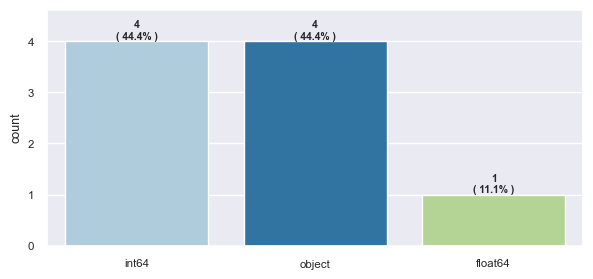

```python
get_feature_countplot(df.dtypes)
```

#### ✅ $\color{darkgreen}{\text{Observations:}}$

- There are **4 integer columns**: "order_id", "customer_id", "food_preparation_time", and "delivery_time", **4 object columns**: "restaurant_name", "cuisine_type", "day_of_the_week", and "rating", and **1 float column**: "cost_of_the_order".
- **All columns have 1898 observations**, **no missing values** are observed in this approach.
- "restaurant_name", "cuisine_type", "day_of_the_week", and "rating" are read as an 'object' data type, but they should be categorical.
- "order_id" and "customer_id" are identifiers. They should not be treated as numerica values.
- No datetime columns included in the dataset.

### **Question 3:** Are there any missing values in the data? If yes, treat them using an appropriate method. [1 mark]

```python
# Counting missing values
df.isna().sum()
```

```
order_id                 0
customer_id              0
restaurant_name          0
cuisine_type             0
cost_of_the_order        0
day_of_the_week          0
rating                   0
food_preparation_time    0
delivery_time            0
dtype: int64
```

```python
# Reviewing unique values to identify if there is any missing information
def getting_unique_values(df, columns):
    for col in columns:
        print('**{}**\n{}\n\n'.format(col, df[col].unique()))

getting_unique_values(df, ['cuisine_type', 'day_of_the_week', 'rating'])
```

```
**cuisine_type**
['Korean' 'Japanese' 'Mexican' 'American' 'Indian' 'Italian'
 'Mediterranean' 'Chinese' 'Middle Eastern' 'Thai' 'Southern' 'French'
 'Spanish' 'Vietnamese']


**day_of_the_week**
['Weekend' 'Weekday']


**rating**
['Not given' '5' '3' '4']
```

```python
# Reviewing how many rows have 'Not given' in rating column.
df.rating.value_counts()
```

```
Not given    736
5            588
4            386
3            188
Name: rating, dtype: int64
```

```python
# Reviewing strange values in numerical columns
(df.select_dtypes(np.number) < 0).any().any()
```

```
False
```

#### ✅ $\color{darkgreen}{\text{Observations:}}$

- In the rating column, we have **736 values without rating provided**, instead the value has "not given". It is recommendable not to try to replace it and treat it as another category.
- Rest of the columns has no missing values.

### **Question 4:** Check the statistical summary of the data. What is the minimum, average, and maximum time it takes for food to be prepared once an order is placed? [2 marks]

```python
df['rating_value'] = pd.to_numeric(df.rating, errors='coerce')
df['total_order_time'] = df.delivery_time + df.food_preparation_time
```

```python
# Statistical summary, including no numerical data.
df.describe(include='all').T
```

|  | count | unique | top | freq | mean | std | min | 25% | 50% | 75% | max |
| --- | --- | --- | --- | --- | --- | --- | --- | --- | --- | --- | --- |
| order_id | 1898.0 | NaN | NaN | NaN | 1477495.5 | 548.049724 | 1476547.0 | 1477021.25 | 1477495.5 | 1477969.75 | 1478444.0 |
| customer_id | 1898.0 | NaN | NaN | NaN | 171168.478398 | 113698.139743 | 1311.0 | 77787.75 | 128600.0 | 270525.0 | 405334.0 |
| restaurant_name | 1898 | 178 | Shake Shack | 219 | NaN | NaN | NaN | NaN | NaN | NaN | NaN |
| cuisine_type | 1898 | 14 | American | 584 | NaN | NaN | NaN | NaN | NaN | NaN | NaN |
| cost_of_the_order | 1898.0 | NaN | NaN | NaN | 16.498851 | 7.483812 | 4.47 | 12.08 | 14.14 | 22.2975 | 35.41 |
| day_of_the_week | 1898 | 2 | Weekend | 1351 | NaN | NaN | NaN | NaN | NaN | NaN | NaN |
| rating | 1898 | 4 | Not given | 736 | NaN | NaN | NaN | NaN | NaN | NaN | NaN |
| food_preparation_time | 1898.0 | NaN | NaN | NaN | 27.37197 | 4.632481 | 20.0 | 23.0 | 27.0 | 31.0 | 35.0 |
| delivery_time | 1898.0 | NaN | NaN | NaN | 24.161749 | 4.972637 | 15.0 | 20.0 | 25.0 | 28.0 | 33.0 |
| rating_value | 1162.0 | NaN | NaN | NaN | 4.344234 | 0.741478 | 3.0 | 4.0 | 5.0 | 5.0 | 5.0 |
| total_order_time | 1898.0 | NaN | NaN | NaN | 51.53372 | 6.833603 | 35.0 | 47.0 | 52.0 | 56.0 | 68.0 |

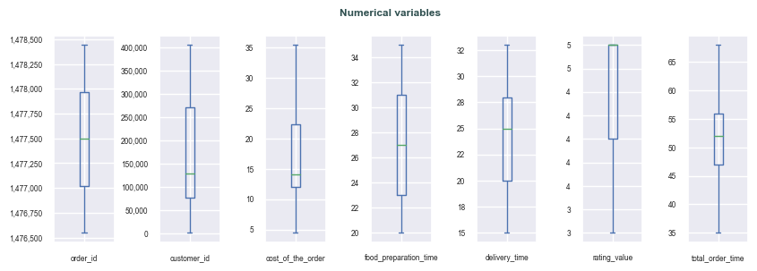

```python
# Visualizing the five-number summary of the numerical variable
get_df_boxplot(df)
```

#### ✅ $\color{darkgreen}{\text{Observations:}}$

- **The average food preparation time is aprox. 27min. 50% of orders takes between 20min and 27min. The minimum time is 20 min, meanwhile the maximum is 35min.**
- There are 178 different restaurants in the dataset.
- The variable 'cuisine_type' has 14 unique categories. The American food is the most frequenty.
- The average cost of orders is aprox *USD \$ 16.50*. The 50% of orders are between *USD \$ 12.08* and *USD \$ 22.29*. The minimum value is *USD \$ 4.47* and the maximum value is *USD \$ 35.41*.
- Weekends are more frequent than weekdays.
- The variable 'rating' has 4 unique categories, including 'Not given'. There is no category for 1 or 2 rates. Less than 25\% of rated orders have 3 as calification.
- The average delivery time is aprox 24min. The 50% of orders takes between 15min and 25min.
- The average total order time is aprox 52 min. The 50% of orders takes between 47min and 56min.
- The order_id and customer_id variables, even when they are integers, should not be treated as numeric values.
- Finally, there is no outliers to report in these approach.

### **Question 5:** How many orders are not rated? [1 mark]

```python
# Reviewing rating values (Using float values)
df.rating_value.isnull().sum()
```

```
736
```

```python
# Getting how many rows are inn each rating category.
get_value_counts(df.rating)
```

|  | Counts | Percent |
| --- | --- | --- |
| Not given | 736 | 0.387777 |
| 5 | 588 | 0.309800 |
| 4 | 386 | 0.203372 |
| 3 | 188 | 0.099052 |

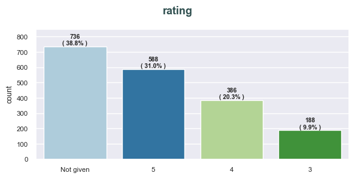

```python
# Countplot of df.rating
get_feature_countplot(df.rating)
```

#### ✅ $\color{darkgreen}{\text{Observations:}}$

- **Aprox. 39\% of orders (736 orders) are not rated**. This can be treated as new category in dataset.
- There is no data collected for ratings 1 and 2.

### Exploratory Data Analysis (EDA)

### **Question 6:** Explore all the variables and provide observations on their distributions. (Generally, histograms, boxplots, countplots, etc. are used for univariate exploration.) [9 marks]

#### ** Numerical Variables

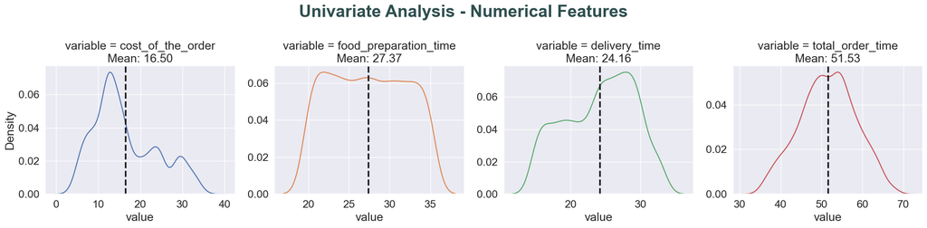

```python
# Taking a look on the distribution at once
get_df_displot(df[['cost_of_the_order', 'food_preparation_time',
                   'delivery_time', 'total_order_time']])
```

#### cost_of_the_order

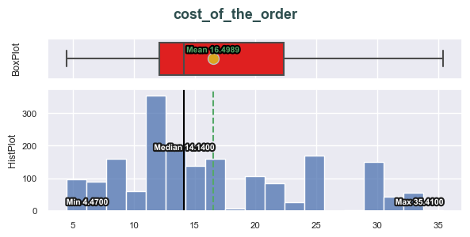

```python
# Going deeper into numerical variables
get_feature_hist_and_boxplot(df.cost_of_the_order)
```

#### food_preparation_time

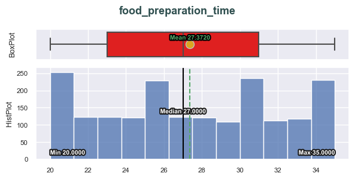

```python
# Going deeper into numerical variables
get_feature_hist_and_boxplot(df.food_preparation_time)
```

#### delivery_time

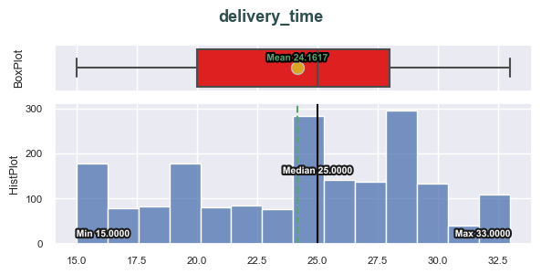

```python
# Going deeper into numerical variables
get_feature_hist_and_boxplot(df.delivery_time)
```

#### total_order_time

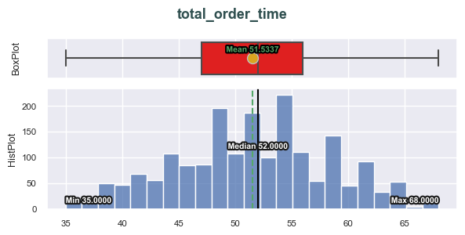

```python
# Going deeper into numerical variables
get_feature_hist_and_boxplot(df.total_order_time)
```

#### cuisine_type

```python
get_value_counts(df.cuisine_type)
```

|  | Counts | Percent |
| --- | --- | --- |
| American | 584 | 0.307692 |
| Japanese | 470 | 0.247629 |
| Italian | 298 | 0.157007 |
| Chinese | 215 | 0.113277 |
| Mexican | 77 | 0.040569 |
| Indian | 73 | 0.038462 |
| Middle Eastern | 49 | 0.025817 |
| Mediterranean | 46 | 0.024236 |
| Thai | 19 | 0.010011 |
| French | 18 | 0.009484 |
| Southern | 17 | 0.008957 |
| Korean | 13 | 0.006849 |
| Spanish | 12 | 0.006322 |
| Vietnamese | 7 | 0.003688 |

```python
cuisine = get_value_counts(df.cuisine_type)[:4].Percent.sum()
print(f'''
The American, Japanese, Italian, and Chinese cuisine types accumulate
{cuisine*100:.0f}% of placed orders.
''')
```

```
The American, Japanese, Italian, and Chinese cuisine types accumulate
83% of placed orders.
```

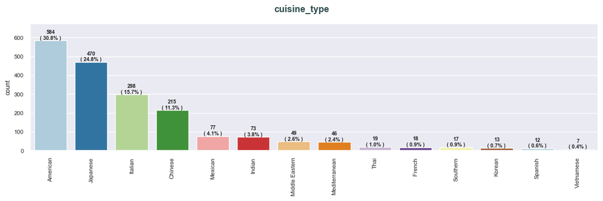

```python
get_feature_countplot(df.cuisine_type, rotation=90, figsize=(12,4))
```

#### day_of_the_week

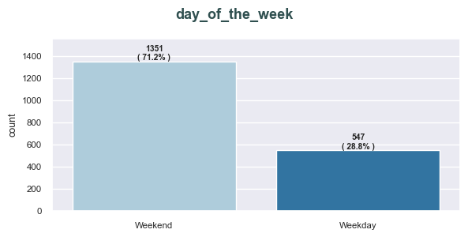

```python
get_feature_countplot(df.day_of_the_week)
```

#### rating

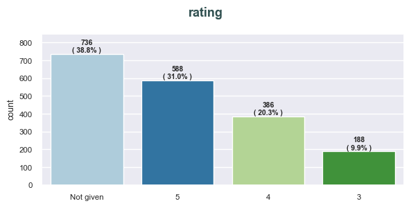

```python
get_feature_countplot(df.rating)
```

#### ** Other variables

```python
# Getting unique values of features not numeric/categorical
get_unique_values(df[['order_id', 'customer_id', 'restaurant_name']])
```

```
--------------------------------------------------
order_id             : 1898, repeated: 0.0000
--------------------------------------------------
customer_id          : 1200, repeated: 0.3678
--------------------------------------------------
restaurant_name      :  178, repeated: 0.9062
--------------------------------------------------
```

#### ✅ $\color{darkgreen}{\text{Observations:}}$

- Each record has the detail of an order. There are 1898 different orders collected. No repeated records.
- There are 1200 different clients in the collected data. Around 36% have requested an order more than one time.
- There are 178 different restaurants where clients can ask for food.
- The cost of orders shows a right-skewed distribution with a mean of approx. *USD \$ 16.5* per order. The 50% of orders are below USD 14.14.
- Food preparation time shows an interesting multimodal distribution with 4 peaks. There is not much variation in the rest of the collected data. The mean and median are approx. equal to 27 min.
- The delivery time has a left-skewed distribution. Half of the orders took less than 25 min to be delivered after the preparation is completed.
- The total order time seems to have a normalized distribution with a mean and median of approx. 52min.
- There are 14 different cuisine types in the data collected. American food is the most popular (30.8%) followed by Japanese (24.8%), Italian (15.7%), and Chinese (11.3%). These four cuisine types accumulate 83% of placed orders.
- 71.2% of orders are placed during the weekend.
- In rating, the percentage of not given value is 38.8%, and treated as a category, belongs to the greatest frequency. Other values are 5 (31%), 4 (20.3%), and 3 (9.9%).

### **Question 7**: Which are the top 5 restaurants in terms of the number of orders received? [1 mark]

```python
# Getting the 5 most frequent restaurants
df_top5_restaurants = get_value_counts(df.restaurant_name, 5)
df_top5_restaurants
```

|  | Counts | Percent |
| --- | --- | --- |
| Shake Shack | 219 | 0.115385 |
| The Meatball Shop | 132 | 0.069547 |
| Blue Ribbon Sushi | 119 | 0.062698 |
| Blue Ribbon Fried Chicken | 96 | 0.050580 |
| Parm | 68 | 0.035827 |

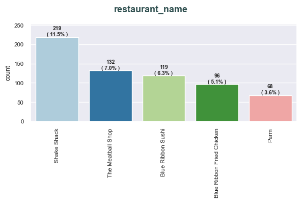

```python
# Top 5 restaurants
get_feature_countplot(df.restaurant_name, rotation=90, top=5, figsize=(6,4))
```

```python
top_restaurant = df.groupby('restaurant_name').agg({
    'order_id':'count',
    'cuisine_type':'max',
    'customer_id': 'nunique'
}).sort_values('order_id', ascending=False)[:5]
top_restaurant.columns = ['order_count', 'cuisine_type', 'unique_customers']
top_restaurant['repeated'] =  1 - (top_restaurant.unique_customers * 1.0) / top_restaurant.order_count
top_restaurant
```

| restaurant_name | order_count | cuisine_type | unique_customers | repeated |
| --- | --- | --- | --- | --- |
| Shake Shack | 219 | American | 170 | 0.223744 |
| The Meatball Shop | 132 | Italian | 102 | 0.227273 |
| Blue Ribbon Sushi | 119 | Japanese | 75 | 0.369748 |
| Blue Ribbon Fried Chicken | 96 | American | 68 | 0.291667 |
| Parm | 68 | Italian | 56 | 0.176471 |

#### ✅ $\color{darkgreen}{\text{Observations:}}$

- In terms of the number of orders received, these are the top 5 restaurants: **"Shake Shack"** is the most frequent restaurant (11.5%), followed by **"The Meatball Shop"** (7%), **"Blue Ribbon Sushi"** (6%), **"Blue Ribbon Fried Chicken"** (5%), and **"Parm"** (4%).
- In these restaurants, between 17% and 37% of clients have requested food from the same restaurant more than once.
- These restaurants belongs to American, Italian, and Japanese cuisine type.

### **Question 8**: Which is the most popular cuisine on weekends? [1 mark]

```python
# Get the most popular cuisine on weekends
get_value_counts(df[df.day_of_the_week == 'Weekend'].cuisine_type, top=1)
```

|  | Counts | Percent |
| --- | --- | --- |
| American | 415 | 0.30718 |

```python
# Get the most popular cuisine on weekends
get_value_counts(df[df.day_of_the_week == 'Weekday'].cuisine_type, top=1)
```

|  | Counts | Percent |
| --- | --- | --- |
| American | 169 | 0.308958 |

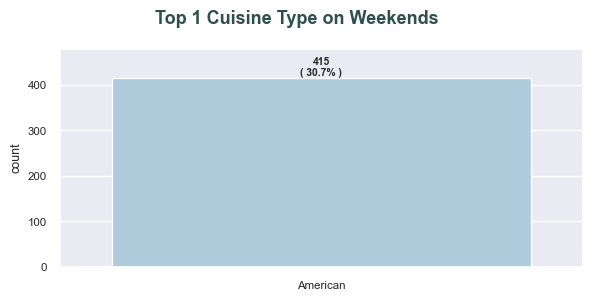

```python
# Visualizing most popular cuisine on weekends
get_feature_countplot(df[df.day_of_the_week == 'Weekend'].cuisine_type,
                      top=1, title='Top 1 Cuisine Type on Weekends')
```

#### ✅ $\color{darkgreen}{\text{Observations:}}$

- **American cuisine** remains a favorite even on the weekends. It is the most popular cuisine even on weekends, 31% of weekend orders are American cuisine.

### **Question 9**: What percentage of the orders cost more than 20 dollars? [2 marks]

```python
# Getting the percentage of orders with a cost greater than 20 dollars.
orders_20 = df[df.cost_of_the_order > 20]
print("""
The number of total orders that cost above USD 20 is: {} (from {} collected samples)
Percentage of orders above 20 dollars: {:.2%}
""".format(len(orders_20), len(df), len(orders_20) / len(df)))
```

```
The number of total orders that cost above USD 20 is: 555 (from 1898 collected samples)
Percentage of orders above 20 dollars: 29.24%
```

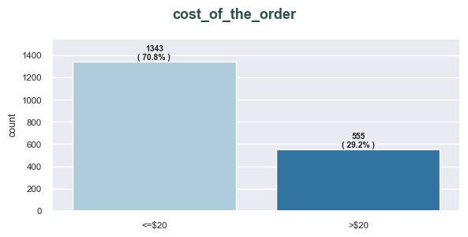

```python
get_feature_countplot(df.cost_of_the_order.map(lambda x: '>$20' if x>20 else '<=$20'))
```

#### ✅ $\color{darkgreen}{\text{Observations:}}$

- **29.24% of orders cost more than 20 dollars**. This represents 555 records from a total of 1,898 orders.

### **Question 10**: What is the mean order delivery time? [1 mark]

```python
# Getting the mean order deliver time.
df.delivery_time.mean()
```

```
24.161749209694417
```

```
Total order time distribution in percentages:
delivery_time            0.468853
food_preparation_time    0.531147
dtype: float64
```

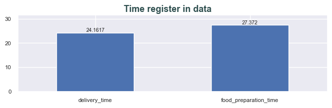

```python
feature = df.mean(numeric_only=True).loc[['delivery_time', 'food_preparation_time']]
print('Total order time distribution in percentages:', feature/feature.sum(), sep='\n')
get_feature_barplot(feature, title='Time register in data')
```

#### ✅ $\color{darkgreen}{\text{Observations:}}$

- **The average order delivery time in the data collected is approx. 24 min**. This value represents 47% of the total average order time.

### **Question 11:** The company has decided to give 20% discount vouchers to the top 3 most frequent customers. Find the IDs of these customers and the number of orders they placed. [1 mark]

```python
# Getting the 3 top customers in data collected.
get_value_counts(df.customer_id, 3)
```

|  | Counts | Percent |
| --- | --- | --- |
| 52832 | 13 | 0.006849 |
| 47440 | 10 | 0.005269 |
| 83287 | 9 | 0.004742 |

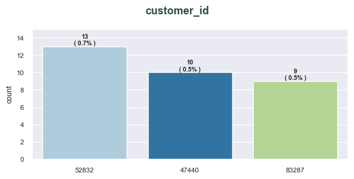

```python
get_feature_countplot(df.customer_id, top=3)
```

#### ✅ $\color{darkgreen}{\text{Observations:}}$

- **The top most fequent customers have the ids: 52832 (13 placed orders), 47440 (10 placed order), and 83287 (9 placed order)**.

### **Question 12**: Perform a multivariate analysis to explore relationships between the important variables in the dataset. (It is a good idea to explore relations between numerical variables as well as relations between numerical and categorical variables) [10 marks]

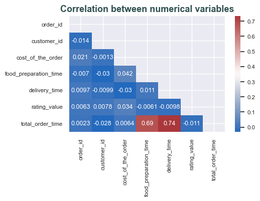

```python
# Reviewing the correlation between variables
get_df_correlation(df)
```

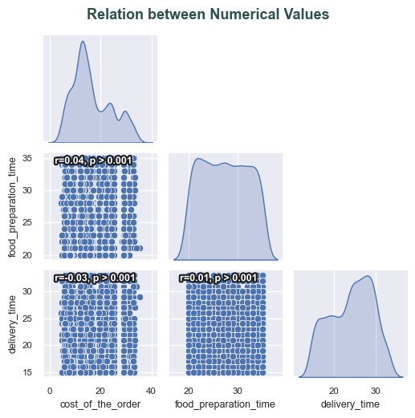

```python
# Reviewing in detail the relation between numerical values, using Pairplot
get_df_pairplot(df[['cost_of_the_order', 'food_preparation_time', 'delivery_time']])
```

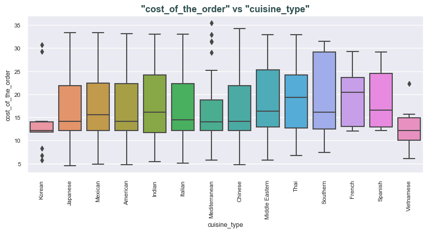

```python
# Relation between cost of the orders and cuisine type.
get_3var_relation_boxplot(df, 'cuisine_type', 'cost_of_the_order')
```

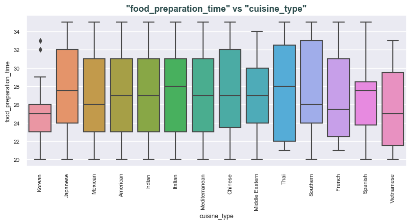

```python
# Relation between food preparation time and cuisine type.
get_3var_relation_boxplot(df, 'cuisine_type', 'food_preparation_time')
```

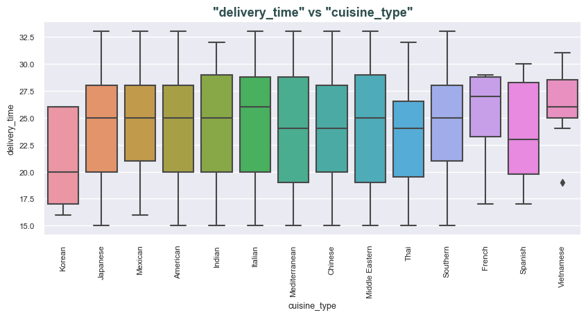

```python
# Relation between delivery time and cuisine type.
get_3var_relation_boxplot(df, 'cuisine_type', 'delivery_time')
```

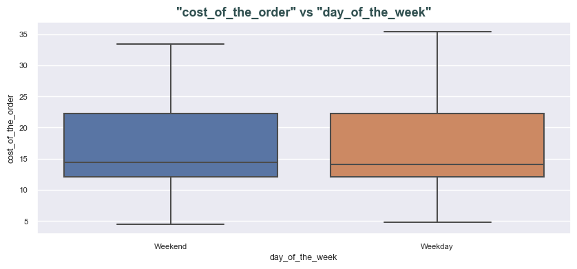

```python
# Relation between cost of the orders and day of the week.
get_3var_relation_boxplot(df, 'day_of_the_week', 'cost_of_the_order', rotation=0)
```

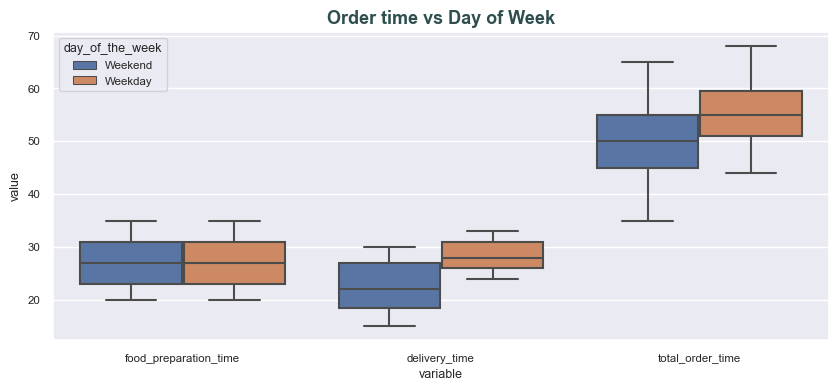

```python
# Preparing the data to plot the relation between "food_preparation_time", "delivery_time",
# "total_order_time"
# and "day_of_the_week"
cols = ["food_preparation_time", "delivery_time", "total_order_time", "day_of_the_week"]
df_timeorder = df[cols].melt(id_vars='day_of_the_week')

get_3var_relation_boxplot(df_timeorder, 'variable', 'value', 'day_of_the_week', rotation=0,
                              title="Order time vs Day of Week")
```

```python
# Getting the top 10 and botton 10 restaurants.
top_10_restaurants = df.restaurant_name.value_counts().head(10).index
bottom_10_restaurants = df.restaurant_name.value_counts().tail(10).index
```

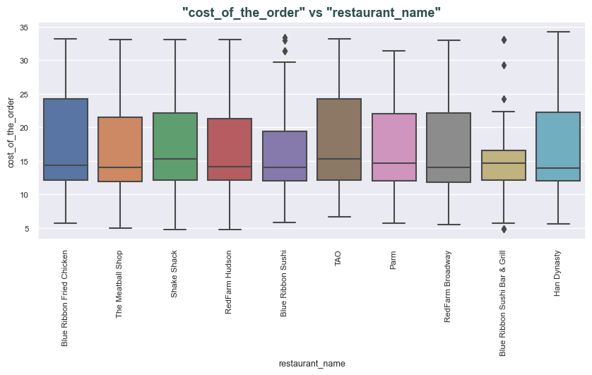

```python
# Relation between cost of the order and top 10 restaurants.
get_3var_relation_boxplot(df[df.restaurant_name.isin(top_10_restaurants)],
                          'restaurant_name', 'cost_of_the_order')
```

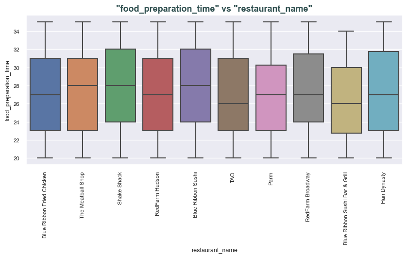

```python
# Relation between food preparation time and top 10 restaurants.
get_3var_relation_boxplot(df[df.restaurant_name.isin(top_10_restaurants)],
                          'restaurant_name', 'food_preparation_time')
```

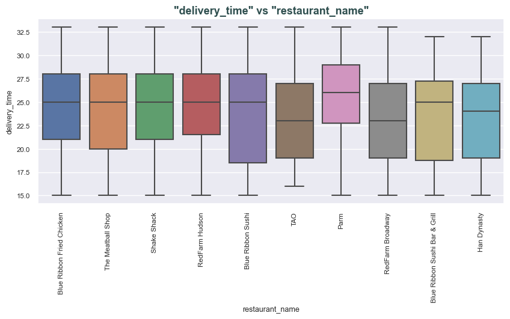

```python
# Relation between delivery time and top 10 restaurants.
get_3var_relation_boxplot(df[df.restaurant_name.isin(top_10_restaurants)],
                          'restaurant_name', 'delivery_time')
```

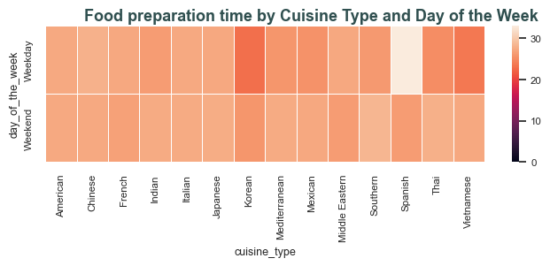

```python
# Heatmap to show the relation between food preparation time and cuisine type.
df_heat = df.pivot_table(index = 'cuisine_type', columns = 'day_of_the_week',
                         values = 'food_preparation_time')
get_heatmap(df_heat.T, title='Food preparation time by Cuisine Type and Day of the Week')
```

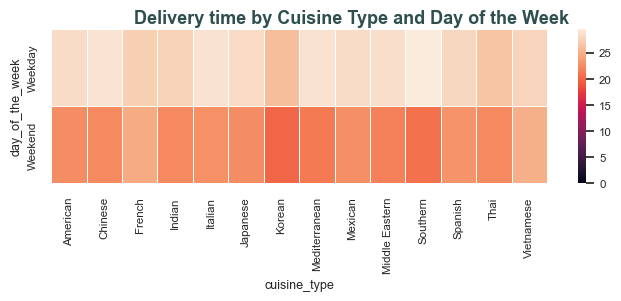

```python
# Heatmap to show the relation between delivery time and cuisine type.
df_heat = df.pivot_table(index = 'cuisine_type', columns = 'day_of_the_week',
                         values = 'delivery_time')
get_heatmap(df_heat.T, title='Delivery time by Cuisine Type and Day of the Week')
```

```python
# Revenue generated by restaurant
df.groupby(['restaurant_name'])['cost_of_the_order'].sum().sort_values(ascending = False).head(10)
```

```
restaurant_name
Shake Shack                      3579.53
The Meatball Shop                2145.21
Blue Ribbon Sushi                1903.95
Blue Ribbon Fried Chicken        1662.29
Parm                             1112.76
RedFarm Broadway                  965.13
RedFarm Hudson                    921.21
TAO                               834.50
Han Dynasty                       755.29
Blue Ribbon Sushi Bar & Grill     666.62
Name: cost_of_the_order, dtype: float64
```

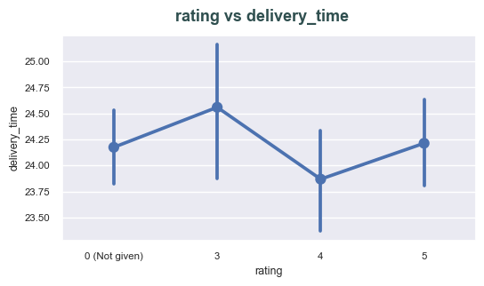

```python
# Relationship between rating and delivery time

df_ratings = df.copy()
df_ratings['rating'] = df_ratings.rating.replace('Not given', '0 (Not given)')
df_ratings = df_ratings.sort_values('rating')
get_df_pointplot(df_ratings.rating, df_ratings.delivery_time)
```

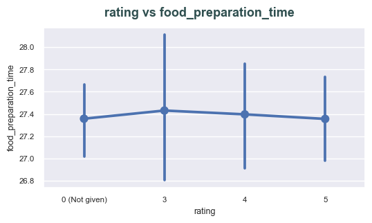

```python
# Relationship between rating and food preparation time
get_df_pointplot(df_ratings.rating, df_ratings.food_preparation_time)
```

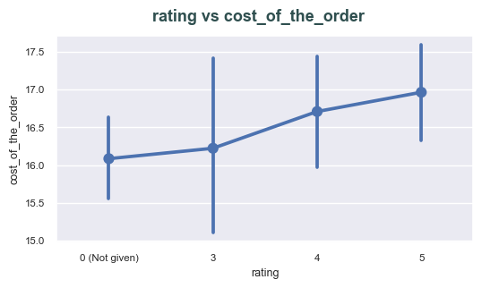

```python
# Relationship between rating and cost of the order
get_df_pointplot(df_ratings.rating, df_ratings.cost_of_the_order)
```

#### ✅ $\color{darkgreen}{\text{Observations:}}$

- There is no significative correlation between the original numerical variables. The "total_order_time" shows a correlation with "food_preparation_time" and "delivery_time" because these variables create it.
- "cost_of_the_order", "food_preparation_time", and "delivery_time" are independent each other.
- There are some outliers in the "cost_of_the_order" when the cuisine_type is Korean, Mediterranean, and Vietnamese. This needs to be investigated a little bit more.
- The highest median for the order cost belongs to the French cuisine type. Chinese food reaches some of the highest order costs in the dataset.
- There are some outliers in the "food_preparation_time" when the cuisine_type is Korean.
- An outlier is found in the "delivery_time" when the cuisine_type is Vietnamese.
- Cost of orders shows approximately the same median no matter if they are registered on weekends or on weekdays.
- Globally, the median of food preparation time is the same no matter if it is a weekend or a weekday.
- There is an increase in the media for the delivery time when is a weekday, this could be related to highest-traffic on weekdays. A register of the order time hour could help to dig a little bit more.
- The media of food preparation time does not variate too much between the top ten restaurants. There is more variation in the delivery time for these same top ten restaurants.
- Spanish food takes more time on weekdays than on weekends. Are there more orders on weekends than on weekdays?
- Korean food takes more time on weekends than on weekdays. Are there fewer people working in the cuisine on weekends?
- The cost of the orders related to the top 10 restaurants shows similar media, and the majority looks like they have a right-skewed distribution. Also, there are some outliers for 2 of these top 10 restaurants.
- The lowest registered rating in the collected data has the highest average delivery time.
- Even though it looks like the lowest registered rating is associated with the highest average delivery time, the spread of the data is big in comparison with the other categories. More analysis is required to verify if this relation is significant.
- The highest rating has also the highest average cost of the orders. Highest cost are related with highest quality.

### **Question 13:** The company wants to provide a promotional offer in the advertisement of the restaurants. The condition to get the offer is that the restaurants must have a rating count of more than 50 and the average rating should be greater than 4. Find the restaurants fulfilling the criteria to get the promotional offer. [3 marks]

```python
# Preparing the data to calculate the total rating counts and average rating
df_promotion = (df.groupby('restaurant_name')
                  .agg({'rating_value': ['mean', 'count'],
                        'order_id': 'count'}))
df_promotion.columns = ['rating_mean', 'rating_count', 'total_orders']

# Calculating how many orders do not provide any rates, in percentage.
df_promotion['percent_missing_rates'] = 1 - (df_promotion.rating_count / df_promotion.total_orders)

# Sorting and filtering the data
df_promotion = df_promotion[(df_promotion.rating_count>50) & (df_promotion.rating_mean>4)]
df_promotion = df_promotion.sort_values(['rating_mean', 'rating_count'], ascending=False)
df_promotion
```

| restaurant_name | rating_mean | rating_count | total_orders | percent_missing_rates |
| --- | --- | --- | --- | --- |
| The Meatball Shop | 4.511905 | 84 | 132 | 0.363636 |
| Blue Ribbon Fried Chicken | 4.328125 | 64 | 96 | 0.333333 |
| Shake Shack | 4.278195 | 133 | 219 | 0.392694 |
| Blue Ribbon Sushi | 4.219178 | 73 | 119 | 0.386555 |

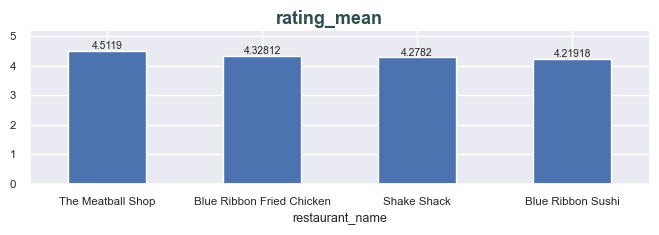

```python
# Which restaurants have more than
get_feature_barplot(df_promotion.rating_mean)
```

#### ✅ $\color{darkgreen}{\text{Observations:}}$

- The restaurants, that have a rating count greater than 50 and an average rating greater than 4, are: **The Meatball Shop* (avg. rate: 4.5),** Blue Ribbon Fried Chicken **(avg. rate: 4.3),** Shake Shack **(avg. rate: 4.3), and** Blue Ribbon Sushi** (avr. rate: 4.2).
- The Meatball Shop is the restaurant with the highest rating.
- Even though Shake Shack is the most popular restaurant, it is not the one with the highest rating. More analysis could confirm if this difference in ratings is significant and what is the motivation behind them.